# Kansrekening

Witek ten Hove

15 November 2017

*Onderstaande is een bewerking van college 1.2 van de cursus “Statistics and Probability in Data Science using Python” (UCSanDiegoX - DSE210x) op [Coursera](https://www.coursera.org/).*

Stel we hebben een munt en gooien deze $k$ maal. Bij kop is $x$ gelijk aan 1 en bij munt -1. De kans dat we kop of munt gooien is 50% en dit betekent dat de verwachte waarde van de som van uitkomsten van alle worpen gelijk is aan 0 (nul):

$$S = \sum_{i=1}^{k} x_i$$
$$\mathbf{E}(S) = 0$$

Als we dus voor $k$ een ‘groot’ getal nemen, bijvoorbeeld $k = 100$, dan verwachten we dat $S$ dichtbij nul zal uitkomen. We kunnen dit simuleren door een eerst een worpfunctie te creëren (`generate_counts()`) die `k` keer een munt gooit en deze handeling `n` maal herhaalt. De uitkomsten bewaren we in een matrix (`X`) met dimensie `k` x `n`. Voor iedere serie van `k` worpen berekenen we de som en bewaren die in een vector `S`.

```r
generate_counts <- function(k = 100, n=100) {
  X = matrix(2*(runif(k*n)>0.5)-1, k, n)
  S = colSums(X)
  return(S)
}
```

Nu kunnen we `k` laten variëren (in dit geval door deze met een factor 10 te verhogen) en de waarden van `S` samenvatten in een histogram.

```r
k = 100
lbound = round(-4*k^0.5)
ubound = round(4*k^0.5)
hist(generate_counts(k = k), xlim = range(lbound, ubound), col = "skyblue", main = paste("Histogram of k = " , k, " flips, boundaries = ", ubound))
abline(v=lbound, col="red")
```

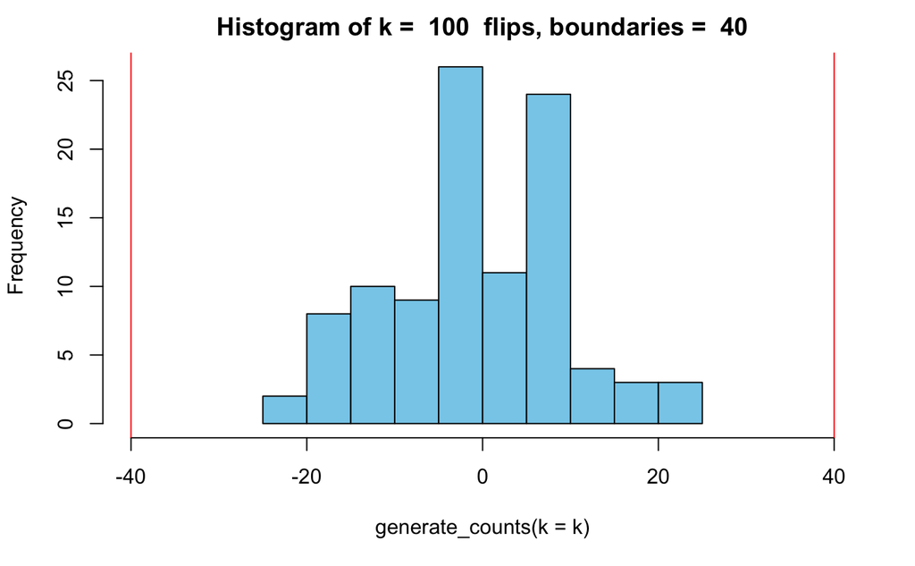

```r
abline(v=ubound, col="red")
```

```r
k = 1000
lbound = round(-4*k^0.5)
ubound = round(4*k^0.5)
hist(generate_counts(k = k), xlim = range(lbound, ubound), col = "tomato", main = paste("Histogram of k = " , k, " flips, boundaries = ", ubound))
abline(v=lbound, col="red")
```

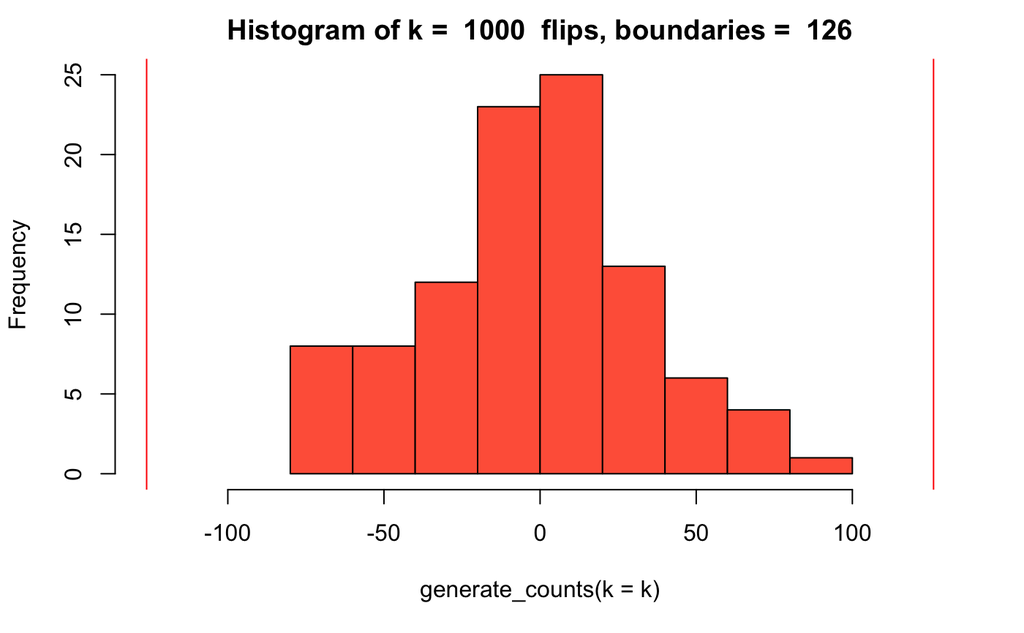

```r
abline(v=ubound, col="red")
```

```r
k = 10000
lbound = round(-4*k^0.5)
ubound = round(4*k^0.5)
hist(generate_counts(k = k), xlim = range(lbound, ubound), col = "gold", main = paste("Histogram of k = " , k, " flips, boundaries = ", ubound))
abline(v=lbound, col="red")
```

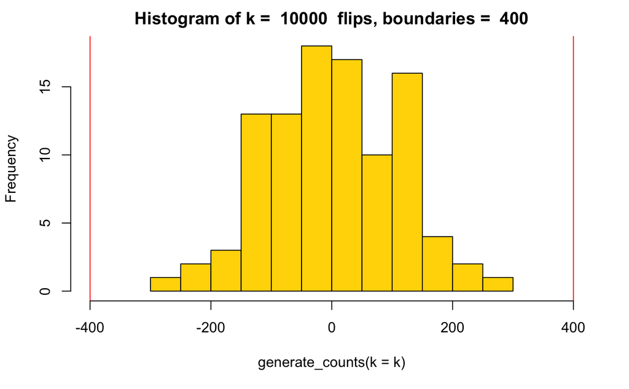

```r
abline(v=ubound, col="red")
```

```r
k = 100000
lbound = round(-4*k^0.5)
ubound = round(4*k^0.5)
hist(generate_counts(k = k), xlim = range(lbound, ubound), col = "mediumaquamarine", main = paste("Histogram of k = " , k, " flips, boundaries = ", ubound))
abline(v=lbound, col="red")
```

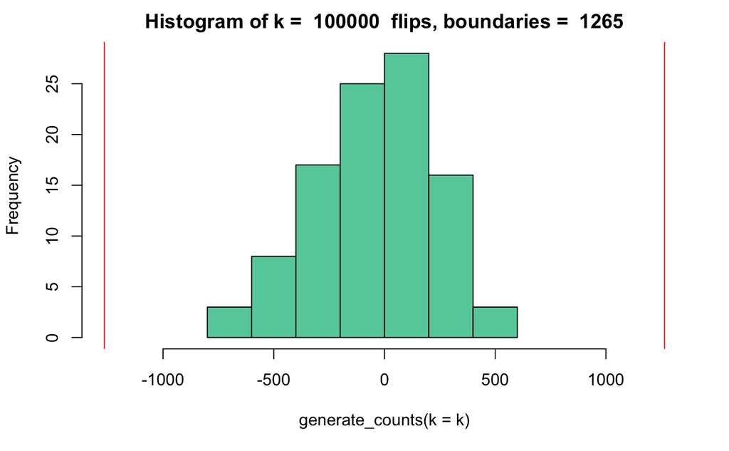

```r
abline(v=ubound, col="red")
```

In bovenstaande grafieken zijn met rode lijnen onder- en bovengrenzen aangegeven (resp. `lbound` en `ubound`) met de waarden $\pm 4*\sqrt{k}$. Later zullen we aantonen dat de kans dat $S_k$, d.w.z. de som van uitkomsten bij een serie van $k$ worpen, buiten de range van $\pm 4*\sqrt{k}$ komt kleiner is dan $2*10^{-8}$ (0.000002%). Zoals we in bovenstaande grafieken kunnen zien, komt inderdaad bij geen enkele simulatie $S$ buiten de rode lijnen.

Als we de schaal op de x-as baseren op de extreme waarden die $S$ theoretisch kan aannemen ($\pm k$), zien we dat de range waartussen $S$ zich met grote waarschijnlijkheid tussen bevindt, relatief smaller wordt naarmate $k$ toeneemt.

```r
generate_counts <- function(k = 1000, n=100) {
  X = matrix(2*(runif(k*n)>0.5)-1, k, n)
  S = colSums(X)
  return(S)
}
k = 100
lbound = round(-4*k^0.5)
ubound = round(4*k^0.5)
hist(generate_counts(k = k), xlim = range(-k, k), col = "skyblue", main = paste("Histogram of k = " , k, " flips, boundaries = ", ubound))
abline(v=lbound, col="red")
```

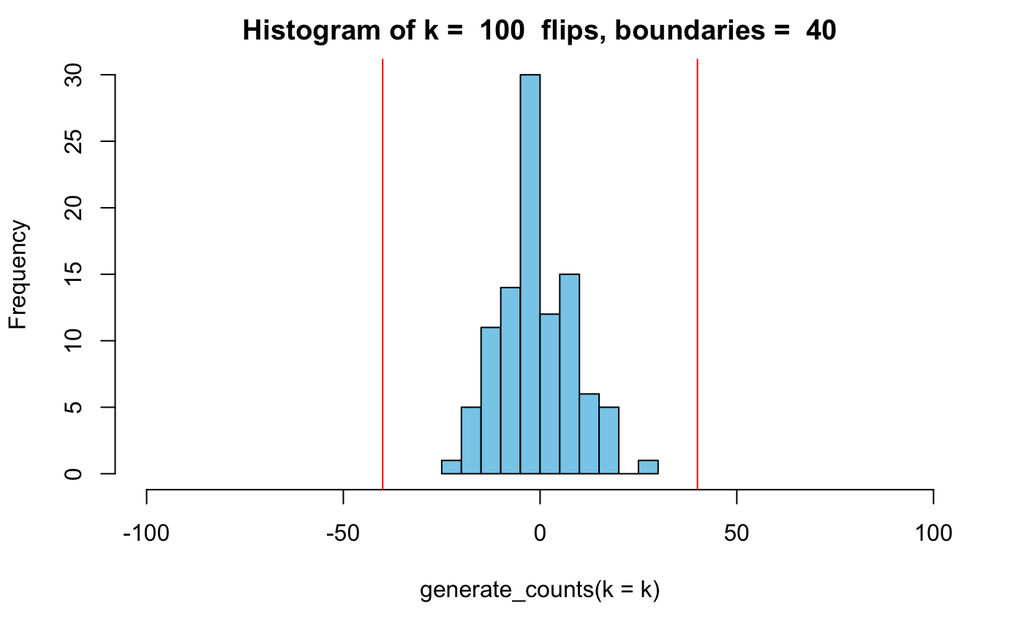

```r
abline(v=ubound, col="red")
```

```r
k = 1000
lbound = round(-4*k^0.5)
ubound = round(4*k^0.5)
hist(generate_counts(k = k), xlim = range(-k, k), col = "tomato", main = paste("Histogram of k = " , k, " flips, boundaries = ", ubound))
abline(v=lbound, col="red")
```

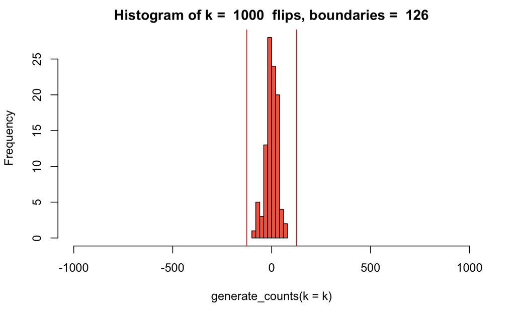

```r
abline(v=ubound, col="red")
```

```r
k = 10000
lbound = round(-4*k^0.5)
ubound = round(4*k^0.5)
hist(generate_counts(k = k), xlim = range(-k, k), col = "gold", main = paste("Histogram of k = " , k, " flips, boundaries = ", ubound))
abline(v=lbound, col="red")
```

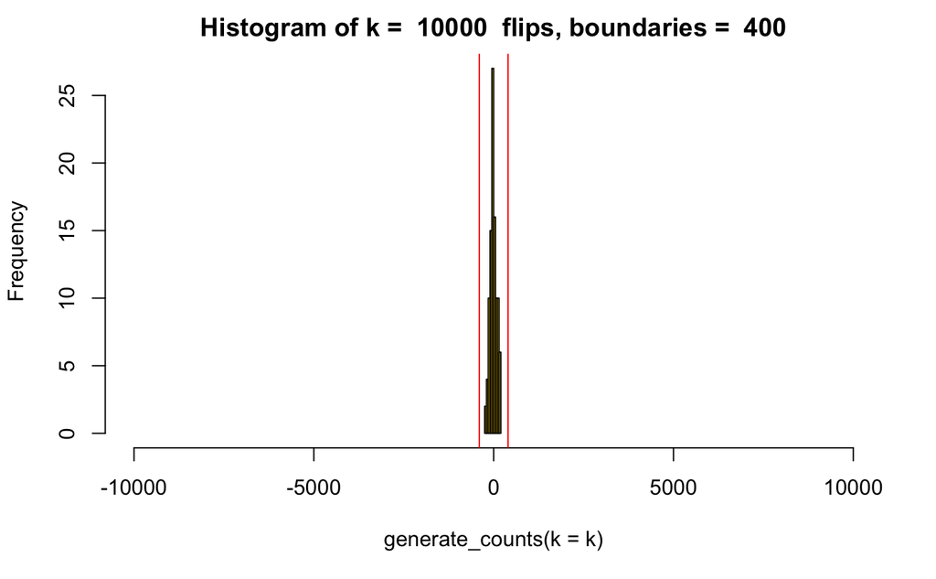

```r
abline(v=ubound, col="red")
```

```r
k = 100000
lbound = round(-4*k^0.5)
ubound = round(4*k^0.5)
hist(generate_counts(k = k), xlim = range(-k, k), col = "mediumaquamarine", main = paste("Histogram of k = " , k, " flips, boundaries = ", ubound))
abline(v=lbound, col="red")
```

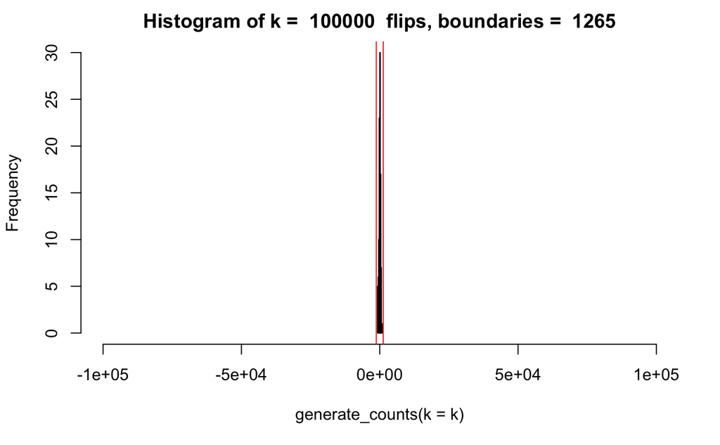

```r
abline(v=ubound, col="red")
```

Wat gebeurt er met de verhouding $\frac {\pm 4*\sqrt{k}}{k}$ als $k\to\infty$?

$$\lim_{k\to\infty} \pm \frac{4*\sqrt{k}}{k} = \lim_{k\to\infty} \pm \frac{4}{\sqrt{k}} = 0$$
En aangezien $S_k$ bijna altijd tussen de berekende onder- en bovengrenzen ligt, betekent dit dat als $k\to\infty$, $\frac{S_k}{k}$ ook naar nul gaat.

De simulaties die we hierboven hebben uitgevoerd worden Monte Carlo simulaties genoemd. We hebben gezien dat als je zekerder wilt zijn van een hypothese je meer simulaties moet doen.

Je zult natuurlijk nooit oneindig muntjes kunnen laten gooien door de computer en op deze wijze dus nooit met absolute zekerheid kunnen bepalen dat de kans op kop of munt 50% is. Het vakgebied Kansrekening gaat over de Wiskunde die nodig is om uitspraken omtrent kansen formeel te bewijzen.